# Moneyball Application: Application of a linear regression model to basketball statistics

Jovi Ong

14/05/2021

## Introduction

The National Basketball Association (NBA) is considered the premier league in the world for men’s basketball. (1) With teams located out of the North American regions, the league is divided into two conferences, Eastern and Western conference, consisting of thirty teams. In an eighty-two games regular season format, each team from their respective conferences competes over several months in order to qualify for the post-season, best of seven games knockout style tournament, also known as the “Playoffs”. (2) With only sixteen spots available, eight teams per conference, a champion from each conference then proceeds onto the Final Series to play for the status of world champions and the Larry O’Brien Trophy.

With a win to loss record of 22 to 60 in the previous 2018/19 season, the Chicago Bulls finished at 27th overall in the league and 13th in their Eastern Conference. (3) Given the lower budget, ranking at 26 out of 30, within the NBA, the general manager of Chicago Bulls is looking to restructure the roster for 2019/20 season in order to provide the franchise with a better opportunity to qualify for the post-season playoffs.

As winning games prove to be much more profitable and beneficial for a team in the NBA (1), many teams have shifted their focus on to statistical analysis in order to increase their capabilities of doing so. (4) However, we first need to understand the metrics involved in winning the game and their correlation to individual player metrics in building a roster that fits the coach’s game plan. Whilst a closer look into box scores have shown winning teams are often considered to be efficient in both the offensive and defensive end of the game, building a team with players that can contribute to the teams’ net efficiency rating, the difference between offensive and defensive rating, depends on individual player attributes. (2) Player attributes that have been linked to each teams’ success have also been narrowed down to the following; (2, 4) - Effective field goal percentages (eFG%) - Turnover percentages (TOV%) - Rebound percentages (ORB% + DRB%) - Free throw rates (FTA/FGM) *FTA – Free throw attempts, FGM – Field goals made, ORB% – Offensive rebound percentage, DRB% - Defensive rebound percentage

However, when selecting players for their positions, Point Guard (PG), Shooting Guard (SG), Small Forward (SF), Power Forward (PF), Centre (C), coaches may consider their PGs as the director of the team on the floor whereby they are expected to be creating opportunities for their scorers, SG and SF, to have an attempt at shot. On the defensive end however, coaches may then consider their ‘BIGs’ (PF and C) to be the main players in preventing the opponent from scoring. (5)

## Reading and Cleaning Raw Data

### Loading library

Firstly we need to load the relevant packages for our library

```r
library(tidyverse)
library(zoo)
library(broom)
```

### Reading data

Then we will need to read in our csv format data files from the local directory into our global environment using the `read_csv()` from the `readr` package.

```r
# reading in the data for all five documents #
file_names <- list.files("data/raw")

for (i in seq_along(file_names)) {

players <- read_csv("data/raw/2018-19_nba_player-statistics.csv")
team_1 <- read_csv("data/raw/2018-19_nba_team-statistics_1.csv")
team_2 <- read_csv("data/raw/2018-19_nba_team-statistics_2.csv")
salary <- read_csv("data/raw/2018-19_nba_player-salaries.csv")
team_salary <- read_csv("data/raw/2019-20_nba_team-payroll.csv")
}
```

The object labels found within the data have been summarised for the ease in analysis. In order to obtain a full list of the data description, click on the link attached, https://unicanberra.instructure.com/courses/9531/pages/data-description-reproducible-data-analysis-project, to access the details

### Checking data

Once completed, the data is then checked by using the following codes

To check the structure of data file using `str()`:

```r
str(players)
```

```
## spec_tbl_df [708 x 29] (S3: spec_tbl_df/tbl_df/tbl/data.frame)
##  $ player_name: chr [1:708] "Alex Abrines" "Quincy Acy" "Jaylen Adams" "Steven Adams" ...
##  $ Pos        : chr [1:708] "SG" "PF" "PG" "C" ...
##  $ Age        : num [1:708] 25 28 22 25 21 21 25 33 21 23 ...
##  $ Tm         : chr [1:708] "OKC" "PHO" "ATL" "OKC" ...
##  $ G          : num [1:708] 31 10 34 80 82 19 7 81 10 38 ...
##  $ GS         : num [1:708] 2 0 1 80 28 3 0 81 1 2 ...
##  $ MP         : num [1:708] 588 123 428 2669 1913 ...
##  $ FG         : num [1:708] 56 4 38 481 280 11 3 684 13 67 ...
##  $ FGA        : num [1:708] 157 18 110 809 486 ...
##  $ FG%        : num [1:708] 0.357 0.222 0.345 0.595 0.576 0.306 0.3 0.519 0.333 0.376 ...
##  $ 3P         : num [1:708] 41 2 25 0 3 6 0 10 3 32 ...
##  $ 3PA        : num [1:708] 127 15 74 2 15 23 4 42 12 99 ...
##  $ 3P%        : num [1:708] 0.323 0.133 0.338 0 0.2 0.261 0 0.238 0.25 0.323 ...
##  $ 2P         : num [1:708] 15 2 13 481 277 5 3 674 10 35 ...
##  $ 2PA        : num [1:708] 30 3 36 807 471 ...
##  $ 2P%        : num [1:708] 0.5 0.667 0.361 0.596 0.588 0.385 0.5 0.528 0.37 0.443 ...
##  $ eFG%       : num [1:708] 0.487 0.278 0.459 0.595 0.579 0.389 0.3 0.522 0.372 0.466 ...
##  $ FT         : num [1:708] 12 7 7 146 166 4 1 349 8 45 ...
##  $ FTA        : num [1:708] 13 10 9 292 226 4 2 412 12 60 ...
##  $ FT%        : num [1:708] 0.923 0.7 0.778 0.5 0.735 1 0.5 0.847 0.667 0.75 ...
##  $ ORB        : num [1:708] 5 3 11 391 165 3 1 251 11 3 ...
##  $ DRB        : num [1:708] 43 22 49 369 432 16 3 493 15 20 ...
##  $ TRB        : num [1:708] 48 25 60 760 597 19 4 744 26 23 ...
##  $ AST        : num [1:708] 20 8 65 124 184 5 6 194 13 25 ...
##  $ STL        : num [1:708] 17 1 14 117 71 1 2 43 1 6 ...
##  $ BLK        : num [1:708] 6 4 5 76 65 4 0 107 0 6 ...
##  $ TOV        : num [1:708] 14 4 28 135 121 6 2 144 8 33 ...
##  $ PF         : num [1:708] 53 24 45 204 203 13 4 179 7 47 ...
##  $ PTS        : num [1:708] 165 17 108 1108 729 ...
##  - attr(*, "spec")=
##   .. cols(
##   ..   player_name = col_character(),
##   ..   Pos = col_character(),
##   ..   Age = col_double(),
##   ..   Tm = col_character(),
##   ..   G = col_double(),
##   ..   GS = col_double(),
##   ..   MP = col_double(),
##   ..   FG = col_double(),
##   ..   FGA = col_double(),
##   ..   `FG%` = col_double(),
##   ..   `3P` = col_double(),
##   ..   `3PA` = col_double(),
##   ..   `3P%` = col_double(),
##   ..   `2P` = col_double(),
##   ..   `2PA` = col_double(),
##   ..   `2P%` = col_double(),
##   ..   `eFG%` = col_double(),
##   ..   FT = col_double(),
##   ..   FTA = col_double(),
##   ..   `FT%` = col_double(),
##   ..   ORB = col_double(),
##   ..   DRB = col_double(),
##   ..   TRB = col_double(),
##   ..   AST = col_double(),
##   ..   STL = col_double(),
##   ..   BLK = col_double(),
##   ..   TOV = col_double(),
##   ..   PF = col_double(),
##   ..   PTS = col_double()
##   .. )
```

```r
str(team_1)
```

```
## spec_tbl_df [30 x 25] (S3: spec_tbl_df/tbl_df/tbl/data.frame)
##  $ Rk    : num [1:30] 1 2 3 4 5 6 7 8 9 10 ...
##  $ Team  : chr [1:30] "Milwaukee Bucks" "Golden State Warriors" "Toronto Raptors" "Utah Jazz" ...
##  $ Age   : num [1:30] 26.9 28.4 27.3 27.3 29.2 26.2 24.9 25.7 25.7 27 ...
##  $ W     : num [1:30] 60 57 58 50 53 53 54 49 49 48 ...
##  $ L     : num [1:30] 22 25 24 32 29 29 28 33 33 34 ...
##  $ PW    : num [1:30] 61 56 56 54 53 51 51 52 50 50 ...
##  $ PL    : num [1:30] 21 26 26 28 29 31 31 30 32 32 ...
##  $ MOV   : num [1:30] 8.87 6.46 6.09 5.26 4.77 4.2 3.95 4.44 3.4 3.33 ...
##  $ SOS   : num [1:30] -0.82 -0.04 -0.6 0.03 0.19 0.24 0.24 -0.54 0.15 -0.57 ...
##  $ SRS   : num [1:30] 8.04 6.42 5.49 5.28 4.96 4.43 4.19 3.9 3.56 2.76 ...
##  $ ORtg  : num [1:30] 114 116 113 111 116 ...
##  $ DRtg  : num [1:30] 105 110 107 106 111 ...
##  $ NRtg  : num [1:30] 8.6 6.4 6 5.2 4.8 4.2 4.1 4.4 3.3 3.4 ...
##  $ Pace  : num [1:30] 103.3 100.9 100.2 100.3 97.9 ...
##  $ FTr   : num [1:30] 0.255 0.227 0.247 0.295 0.279 0.258 0.232 0.215 0.266 0.242 ...
##  $ 3PAr  : num [1:30] 0.419 0.384 0.379 0.394 0.519 0.339 0.348 0.381 0.347 0.292 ...
##  $ TS%   : num [1:30] 0.583 0.596 0.579 0.572 0.581 0.568 0.558 0.567 0.545 0.561 ...
##  $ eFG%  : num [1:30] 0.55 0.565 0.543 0.538 0.542 0.528 0.527 0.534 0.514 0.53 ...
##  $ TOV%  : num [1:30] 12 12.6 12.4 13.4 12 12.1 11.9 11.5 11.7 12.4 ...
##  $ ORB%  : num [1:30] 20.8 22.5 21.9 22.9 22.8 26.6 26.6 21.6 26 21.9 ...
##  $ FT/FGA: num [1:30] 0.197 0.182 0.198 0.217 0.221 0.21 0.175 0.173 0.19 0.182 ...
##  $ DRB%  : num [1:30] 80.3 77.1 77.1 80.3 74.4 77.9 78 77 78.2 76.2 ...
##  $ X23   : logi [1:30] NA NA NA NA NA NA ...
##  $ X24   : logi [1:30] NA NA NA NA NA NA ...
##  $ X25   : logi [1:30] NA NA NA NA NA NA ...
##  - attr(*, "spec")=
##   .. cols(
##   ..   Rk = col_double(),
##   ..   Team = col_character(),
##   ..   Age = col_double(),
##   ..   W = col_double(),
##   ..   L = col_double(),
##   ..   PW = col_double(),
##   ..   PL = col_double(),
##   ..   MOV = col_double(),
##   ..   SOS = col_double(),
##   ..   SRS = col_double(),
##   ..   ORtg = col_double(),
##   ..   DRtg = col_double(),
##   ..   NRtg = col_double(),
##   ..   Pace = col_double(),
##   ..   FTr = col_double(),
##   ..   `3PAr` = col_double(),
##   ..   `TS%` = col_double(),
##   ..   `eFG%` = col_double(),
##   ..   `TOV%` = col_double(),
##   ..   `ORB%` = col_double(),
##   ..   `FT/FGA` = col_double(),
##   ..   `DRB%` = col_double(),
##   ..   X23 = col_logical(),
##   ..   X24 = col_logical(),
##   ..   X25 = col_logical()
##   .. )
```

```r
str(team_2)
```

```
## spec_tbl_df [30 x 25] (S3: spec_tbl_df/tbl_df/tbl/data.frame)
##  $ Rk  : num [1:30] 1 2 3 4 5 6 7 8 9 10 ...
##  $ Team: chr [1:30] "Milwaukee Bucks" "Golden State Warriors" "New Orleans Pelicans" "Philadelphia 76ers" ...
##  $ G   : num [1:30] 82 82 82 82 82 82 82 82 82 82 ...
##  $ MP  : num [1:30] 19780 19805 19755 19805 19830 ...
##  $ FG  : num [1:30] 3555 3612 3581 3407 3384 ...
##  $ FGA : num [1:30] 7471 7361 7563 7233 7178 ...
##  $ FG% : num [1:30] 0.476 0.491 0.473 0.471 0.471 0.467 0.454 0.474 0.464 0.468 ...
##  $ 3P  : num [1:30] 1105 1087 842 889 821 ...
##  $ 3PA : num [1:30] 3134 2824 2449 2474 2118 ...
##  $ 3P% : num [1:30] 0.353 0.385 0.344 0.359 0.388 0.359 0.348 0.366 0.378 0.341 ...
##  $ 2P  : num [1:30] 2450 2525 2739 2518 2563 ...
##  $ 2PA : num [1:30] 4337 4537 5114 4759 5060 ...
##  $ 2P% : num [1:30] 0.565 0.557 0.536 0.529 0.507 0.523 0.51 0.539 0.504 0.543 ...
##  $ FT  : num [1:30] 1471 1339 1462 1742 1853 ...
##  $ FTA : num [1:30] 1904 1672 1921 2258 2340 ...
##  $ FT% : num [1:30] 0.773 0.801 0.761 0.771 0.792 0.814 0.713 0.804 0.726 0.768 ...
##  $ ORB : num [1:30] 762 797 909 892 796 ...
##  $ DRB : num [1:30] 3316 2990 2969 3025 2936 ...
##  $ TRB : num [1:30] 4078 3787 3878 3917 3732 ...
##  $ AST : num [1:30] 2136 2413 2216 2207 1970 ...
##  $ STL : num [1:30] 615 625 610 606 561 546 766 680 679 683 ...
##  $ BLK : num [1:30] 486 525 441 432 385 413 425 437 363 379 ...
##  $ TOV : num [1:30] 1137 1169 1215 1223 1193 ...
##  $ PF  : num [1:30] 1608 1757 1732 1745 1913 ...
##  $ PTS : num [1:30] 9686 9650 9466 9445 9442 ...
##  - attr(*, "spec")=
##   .. cols(
##   ..   Rk = col_double(),
##   ..   Team = col_character(),
##   ..   G = col_double(),
##   ..   MP = col_double(),
##   ..   FG = col_double(),
##   ..   FGA = col_double(),
##   ..   `FG%` = col_double(),
##   ..   `3P` = col_double(),
##   ..   `3PA` = col_double(),
##   ..   `3P%` = col_double(),
##   ..   `2P` = col_double(),
##   ..   `2PA` = col_double(),
##   ..   `2P%` = col_double(),
##   ..   FT = col_double(),
##   ..   FTA = col_double(),
##   ..   `FT%` = col_double(),
##   ..   ORB = col_double(),
##   ..   DRB = col_double(),
##   ..   TRB = col_double(),
##   ..   AST = col_double(),
##   ..   STL = col_double(),
##   ..   BLK = col_double(),
##   ..   TOV = col_double(),
##   ..   PF = col_double(),
##   ..   PTS = col_double()
##   .. )
```

```r
str(salary)
```

```
## spec_tbl_df [576 x 3] (S3: spec_tbl_df/tbl_df/tbl/data.frame)
##  $ player_id  : num [1:576] 206 250 397 256 279 562 89 1 102 323 ...
##  $ player_name: chr [1:576] "Aaron Gordon" "Aaron Holiday" "Abdel Nader" "Al Horford" ...
##  $ salary     : num [1:576] 21590909 1914480 1378242 28928710 4000000 ...
##  - attr(*, "spec")=
##   .. cols(
##   ..   player_id = col_double(),
##   ..   player_name = col_character(),
##   ..   salary = col_double()
##   .. )
```

```r
str(team_salary)
```

```
## spec_tbl_df [30 x 3] (S3: spec_tbl_df/tbl_df/tbl/data.frame)
##  $ team_id: num [1:30] 1 2 3 4 5 6 7 8 9 10 ...
##  $ team   : chr [1:30] "Miami" "Golden State" "Oklahoma City" "Toronto" ...
##  $ salary : chr [1:30] "$153,171,497" "$146,291,276" "$144,916,427" "$137,793,831" ...
##  - attr(*, "spec")=
##   .. cols(
##   ..   team_id = col_double(),
##   ..   team = col_character(),
##   ..   salary = col_character()
##   .. )
```

When checking the first six rows of data using `head()`

```r
head(team_1)
```

```
## # A tibble: 6 x 25
##      Rk Team     Age     W     L    PW    PL   MOV   SOS   SRS  ORtg  DRtg  NRtg
##   <dbl> <chr>  <dbl> <dbl> <dbl> <dbl> <dbl> <dbl> <dbl> <dbl> <dbl> <dbl> <dbl>
## 1     1 Milwa~  26.9    60    22    61    21  8.87 -0.82  8.04  114.  105.   8.6
## 2     2 Golde~  28.4    57    25    56    26  6.46 -0.04  6.42  116.  110.   6.4
## 3     3 Toron~  27.3    58    24    56    26  6.09 -0.6   5.49  113.  107.   6
## 4     4 Utah ~  27.3    50    32    54    28  5.26  0.03  5.28  111.  106.   5.2
## 5     5 Houst~  29.2    53    29    53    29  4.77  0.19  4.96  116.  111.   4.8
## 6     6 Portl~  26.2    53    29    51    31  4.2   0.24  4.43  115.  110.   4.2
## # ... with 12 more variables: Pace <dbl>, FTr <dbl>, 3PAr <dbl>, TS% <dbl>,
## #   eFG% <dbl>, TOV% <dbl>, ORB% <dbl>, FT/FGA <dbl>, DRB% <dbl>, X23 <lgl>,
## #   X24 <lgl>, X25 <lgl>
```

```r
head(team_2)
```

```
## # A tibble: 6 x 25
##      Rk Team       G    MP    FG   FGA `FG%`  `3P` `3PA` `3P%`  `2P` `2PA` `2P%`
##   <dbl> <chr>  <dbl> <dbl> <dbl> <dbl> <dbl> <dbl> <dbl> <dbl> <dbl> <dbl> <dbl>
## 1     1 Milwa~    82 19780  3555  7471 0.476  1105  3134 0.353  2450  4337 0.565
## 2     2 Golde~    82 19805  3612  7361 0.491  1087  2824 0.385  2525  4537 0.557
## 3     3 New O~    82 19755  3581  7563 0.473   842  2449 0.344  2739  5114 0.536
## 4     4 Phila~    82 19805  3407  7233 0.471   889  2474 0.359  2518  4759 0.529
## 5     5 Los A~    82 19830  3384  7178 0.471   821  2118 0.388  2563  5060 0.507
## 6     6 Portl~    82 19855  3470  7427 0.467   904  2520 0.359  2566  4907 0.523
## # ... with 12 more variables: FT <dbl>, FTA <dbl>, FT% <dbl>, ORB <dbl>,
## #   DRB <dbl>, TRB <dbl>, AST <dbl>, STL <dbl>, BLK <dbl>, TOV <dbl>, PF <dbl>,
## #   PTS <dbl>
```

```r
head(team_salary)
```

```
## # A tibble: 6 x 3
##   team_id team          salary
##     <dbl> <chr>         <chr>
## 1       1 Miami         $153,171,497
## 2       2 Golden State  $146,291,276
## 3       3 Oklahoma City $144,916,427
## 4       4 Toronto       $137,793,831
## 5       5 Milwaukee     $130,988,604
## 6       6 Portland      $130,256,600
```

```r
head(players)
```

```
## # A tibble: 6 x 29
##   player_name  Pos     Age Tm        G    GS    MP    FG   FGA `FG%`  `3P` `3PA`
##   <chr>        <chr> <dbl> <chr> <dbl> <dbl> <dbl> <dbl> <dbl> <dbl> <dbl> <dbl>
## 1 Alex Abrines SG       25 OKC      31     2   588    56   157 0.357    41   127
## 2 Quincy Acy   PF       28 PHO      10     0   123     4    18 0.222     2    15
## 3 Jaylen Adams PG       22 ATL      34     1   428    38   110 0.345    25    74
## 4 Steven Adams C        25 OKC      80    80  2669   481   809 0.595     0     2
## 5 Bam Adebayo  C        21 MIA      82    28  1913   280   486 0.576     3    15
## 6 Deng Adel    SF       21 CLE      19     3   194    11    36 0.306     6    23
## # ... with 17 more variables: 3P% <dbl>, 2P <dbl>, 2PA <dbl>, 2P% <dbl>,
## #   eFG% <dbl>, FT <dbl>, FTA <dbl>, FT% <dbl>, ORB <dbl>, DRB <dbl>,
## #   TRB <dbl>, AST <dbl>, STL <dbl>, BLK <dbl>, TOV <dbl>, PF <dbl>, PTS <dbl>
```

```r
head(salary)
```

```
## # A tibble: 6 x 3
##   player_id player_name     salary
##       <dbl> <chr>            <dbl>
## 1       206 Aaron Gordon  21590909
## 2       250 Aaron Holiday  1914480
## 3       397 Abdel Nader    1378242
## 4       256 Al Horford    28928710
## 5       279 Al Jefferson   4000000
## 6       562 Alan Williams    77250
```

To check the last six rows of the data file using `tail()`

```r
tail(team_1)
```

```
## # A tibble: 6 x 25
##      Rk Team     Age     W     L    PW    PL   MOV   SOS   SRS  ORtg  DRtg  NRtg
##   <dbl> <chr>  <dbl> <dbl> <dbl> <dbl> <dbl> <dbl> <dbl> <dbl> <dbl> <dbl> <dbl>
## 1    25 Washi~  26.5    32    50    34    48 -2.9  -0.4  -3.3   111.  114.  -2.8
## 2    26 Atlan~  25.1    29    53    27    55 -6.02 -0.04 -6.06  108.  114.  -5.8
## 3    27 Chica~  24      22    60    21    61 -8.41  0.1  -8.32  105.  113.  -8.4
## 4    28 Phoen~  24      19    63    19    63 -9.34  0.73 -8.61  106.  115.  -9.2
## 5    29 New Y~  23.4    17    65    19    63 -9.21  0.28 -8.93  104.  114.  -9.2
## 6    30 Cleve~  25.2    19    63    19    63 -9.61  0.22 -9.39  108.  118.  -9.9
## # ... with 12 more variables: Pace <dbl>, FTr <dbl>, 3PAr <dbl>, TS% <dbl>,
## #   eFG% <dbl>, TOV% <dbl>, ORB% <dbl>, FT/FGA <dbl>, DRB% <dbl>, X23 <lgl>,
## #   X24 <lgl>, X25 <lgl>
```

```r
tail(team_2)
```

```
## # A tibble: 6 x 25
##      Rk Team       G    MP    FG   FGA `FG%`  `3P` `3PA` `3P%`  `2P` `2PA` `2P%`
##   <dbl> <chr>  <dbl> <dbl> <dbl> <dbl> <dbl> <dbl> <dbl> <dbl> <dbl> <dbl> <dbl>
## 1    25 Detro~    82 19855  3185  7238 0.44    993  2854 0.348  2192  4384 0.5
## 2    26 Miami~    82 19730  3251  7218 0.45    928  2658 0.349  2323  4560 0.509
## 3    27 Chica~    82 19905  3266  7205 0.453   745  2123 0.351  2521  5082 0.496
## 4    28 New Y~    82 19780  3134  7241 0.433   823  2421 0.34   2311  4820 0.479
## 5    29 Cleve~    82 19755  3189  7184 0.444   847  2388 0.355  2342  4796 0.488
## 6    30 Memph~    82 19880  3113  6924 0.45    811  2368 0.342  2302  4556 0.505
## # ... with 12 more variables: FT <dbl>, FTA <dbl>, FT% <dbl>, ORB <dbl>,
## #   DRB <dbl>, TRB <dbl>, AST <dbl>, STL <dbl>, BLK <dbl>, TOV <dbl>, PF <dbl>,
## #   PTS <dbl>
```

```r
tail(team_salary)
```

```
## # A tibble: 6 x 3
##   team_id team       salary
##     <dbl> <chr>      <chr>
## 1      25 Indiana    $110,724,804
## 2      26 Phoenix    $108,692,835
## 3      27 LA Lakers  $107,225,482
## 4      28 Sacramento $101,466,920
## 5      29 Dallas     $86,958,881
## 6      30 Atlanta    $79,180,081
```

```r
tail(players)
```

```
## # A tibble: 6 x 29
##   player_name Pos     Age Tm        G    GS    MP    FG   FGA `FG%`  `3P` `3PA`
##   <chr>       <chr> <dbl> <chr> <dbl> <dbl> <dbl> <dbl> <dbl> <dbl> <dbl> <dbl>
## 1 Ivica Zubac C        21 LAL      33    12   516   112   193 0.580     0     0
## 2 Ivica Zubac C        21 TOT      59    37  1040   212   379 0.559     0     0
## 3 Dario Saric PF       24 PHI      13    13   396    48   132 0.364    21    70
## 4 Dario Saric PF       24 MIN      68    28  1627   256   564 0.454    97   253
## 5 Dario Saric PF       24 TOT      81    41  2023   304   696 0.437   118   323
## 6 Ante Zizic  C        22 CLE      59    25  1082   183   331 0.553     0     0
## # ... with 17 more variables: 3P% <dbl>, 2P <dbl>, 2PA <dbl>, 2P% <dbl>,
## #   eFG% <dbl>, FT <dbl>, FTA <dbl>, FT% <dbl>, ORB <dbl>, DRB <dbl>,
## #   TRB <dbl>, AST <dbl>, STL <dbl>, BLK <dbl>, TOV <dbl>, PF <dbl>, PTS <dbl>
```

```r
tail(salary)
```

```
## # A tibble: 6 x 3
##   player_id player_name     salary
##       <dbl> <chr>            <dbl>
## 1       317 Zach LaVine   19500000
## 2       331 Zach Lofton      77250
## 3       451 Zach Randolph 11692308
## 4       421 Zaza Pachulia  2393887
## 5       495 Zhaire Smith   2615160
## 6       447 Zhou Qi        1378242
```

We then locate the missing values found in the data from the following:

```r
# counting missing values of each dataset #
sum(is.na(team_1))
```

```
## [1] 90
```

```r
sum(is.na(team_2))
```

```
## [1] 0
```

```r
sum(is.na(team_salary))
```

```
## [1] 0
```

```r
sum(is.na(players))
```

```
## [1] 117
```

```r
sum(is.na(salary))
```

```
## [1] 0
```

Upon checking for NA, we can identify that the NA values in player_stats represent a count of 0 where a player’s statistical box score was not present. However, the NA values in the team_stats_1 data frame shows three unidentified columns which were not related to the scores. Therefore, we will be using the `select()` function to eliminate this from our final data:

```
team_1 <- select(team_1, -c(X23, X24, X25))
```

We look further into the data to ensure that we are conforming with the tidyverse ‘tidy’ data rule. First we will rename object names that contains any illegal values to begin such as a numerical or % symbol using `rename()`:

```r
players <- rename(players, player = `player_name`, FGp = `FG%`, x3P = `3P`, x3PA = `3PA`, x3Pp = `3P%`, x2P = `2P`, x2PA = `2PA`, x2Pp = `2P%`, eFGp = `eFG%`, FTp = `FT%`)
team_1 <- rename(team_1, rank = `Rk`, x3PAr = `3PAr`, TSp = `TS%`, eFGp = `eFG%`, TOVp = `TOV%`, ORBp = `ORB%`, DRBp = `DRB%`)
team_2 <- rename(team_2, rank = `Rk`, FGp = `FG%`, x3P = `3P`, x3PA = `3PA`, x3Pp = `3P%`, x2P = `2P`, x2PA = `2PA`, x2Pp = `2P%`, FTp = `FT%`)
salary <- rename(salary, player = `player_name`)
```

A new object is then created for us to refer back to our 2018/19 Chicago Bulls roster in order to determine whether we are able to keep certain players within the team for the upcoming 2019/20 season. The `filter()` function is as below:

```r
chi_team <- players %>%
  group_by(player) %>%
  filter(Tm == "CHI")
```

```
players <- filter(players, Tm != "TOT")

players <- players %>%
  group_by(players, Pos) %>%
  summarise(Age = mean(Age), G = sum(G), GS = sum(GS), MP = sum(MP), FG = sum(FG), FGA = sum(FGA), FGp = round((FG/FGA), 3), x3P = sum(x3P), x3PA = sum(x3PA), x3Pp = round((x3P/x3PA), 3), x2P = sum(x2P), x2PA = sum(x2PA), x2Pp = round((x2P/x2PA), 3), eFGp = (round(((FG + .5 * x3P)/FGA), 3)), FT = sum(FT), FTA = sum(FTA), FTp = round((FT/FTA), 3), ORB = sum(ORB), DRB = sum(DRB), TRB = sum(TRB), AST = sum(AST), STL = sum(STL), BLK = sum(BLK), TOV = sum(TOV), PF = sum(PF), PTS = sum(PTS)) %>%
  ungroup()
```

We will then look to join the two team statistical data sets in order to have a ‘team_stats_final’ data frame for exploratory analysis, this will be done by using `full_join()`

```r
team_final <- full_join(team_1, team_2, by = c("Team"))
team_final <- select(team_final, -c(rank.x, rank.y))
```

### Creating new variables

In order for us to compare player box score statistics in an unbiased way, we need to create new variables that would not take into account minutes played. This is because, some players may have less minutes played but are in fact very effective scorers for the team. However, due to the teams’ roster having more effective players, they may be undervalued.

```r
players <- mutate(players, PTS_per_min = PTS / MP)

players %>%
  summarise(mn = mean(PTS_per_min, na.rm = TRUE),
              sd = sd(PTS_per_min, na.rm = TRUE),
              count = n())
```

```
## # A tibble: 1 x 3
##      mn    sd count
##   <dbl> <dbl> <int>
## 1 0.406 0.159   708
```

```r
players <- players %>%
  mutate(PPM_category = if_else(condition = PTS_per_min < 0.4,
                                true = "below average", false = "above average"))
```

A new variable to categorize players by their field goal shooting ability is also created for us to easily identify players later. A z score of >= 0 for FG is desirable hence we then categorize each player accordingly

```r
players <- players %>%
  mutate(FG_z = (FG - mean(FG)) / sd(FG),
         FG_category = if_else(condition = FG_z <0,
                               true = "below average", false = "above average"))
```

Creating a new variable to categorize players by their effectiveness in Rebound rates, firstly we seek out the mean of the total rebound and then categorize the players as above or below average based on the mean.

```r
players <- mutate(players, RB_per_game = TRB / G)

players %>%
  summarise(mn = mean(RB_per_game, na.rm = TRUE),
            sd = sd(RB_per_game, na.rm = TRUE),
            count = n())
```

```
## # A tibble: 1 x 3
##      mn    sd count
##   <dbl> <dbl> <int>
## 1  3.56  2.49   708
```

```r
players <- players %>%
  mutate(RB_category = if_else(condition = RB_per_game < 3.61,
                               true = "below average", false = "above average"))
```

Creating a new variable to categorize players based on their effectiveness in generating TurnOvers, firstly we seek out the mean of the total

```r
players <- mutate(players, TOV_per_game = TOV / G)

players %>%
  summarise(mn = mean(TOV_per_game, na.rm = TRUE),
            sd = sd(TOV_per_game, na.rm = TRUE),
            count = n())
```

```
## # A tibble: 1 x 3
##      mn    sd count
##   <dbl> <dbl> <int>
## 1  1.03 0.748   708
```

```r
players <- players %>%
  mutate(TOV_category = if_else(condition = TOV_per_game < 1.06,
                                true = "below average", false = "above average"))
```

Creating a new variable to categorize players based on their effectiveness in generating Assists, we will first seek out the mean of the total

```r
players <- players %>%
  mutate(AST_per_game = AST / G)

players %>%
  summarise(mn = mean(AST_per_game, na.rm = TRUE),
            sd = sd(AST_per_game, na.rm = TRUE),
            count = n())
```

```
## # A tibble: 1 x 3
##      mn    sd count
##   <dbl> <dbl> <int>
## 1  1.83  1.64   708
```

```r
players <- players %>%
  mutate(AST_category = if_else(condition = AST_per_game < 2,
                                true = "below average", false = "above average"))
```

Generating more per_game box score statistics for players to assist with analysis

```r
players <- players %>%
  mutate(FG_per_game = FG / G,
         x3P_per_game = x3P / G,
         x2P_per_game = x2P / G,
         FT_per_game = FT / G,
         PTS_per_game = PTS / G)
```

## Exploratory Analysis

### Metrics for a Winning Team Formula

In a paper published by Kubatko et. al., a breakdown of box score statistics were shown to determine the relationship of each variable to the success of a team. In conclusion, the idea of possession being the central concept to winning games were used to compare against other metrics. However, a later study conducted by Mikołajec et al. determined that a heavier lean to offensive ratings have proven to indicate performance success in NBA teams.

Therefore, it was decided that in order to anticipate the outcome of a teams’ success, the offensive variables have been explored within this analysis. Mainly around the relationship of the offensive ratings and wins for a team as well as the individual variables that directly contributes to the offensive ratings. *Teramoto, M and Cross, C stated that the **Four Factors** which breakdowns a teams’ overall efficiency ratings are as follows: a) eFG% b) TOV% c) RB% d) FT*

### Plotting graphs to examine the relationship between variables

The following string of line shows the plots that we are creating using the `ggplot()` function to assess the four variables of FG_per_game, RB_per_game, TOV_per_game and FT_per_game to the success of PTS_per_game.

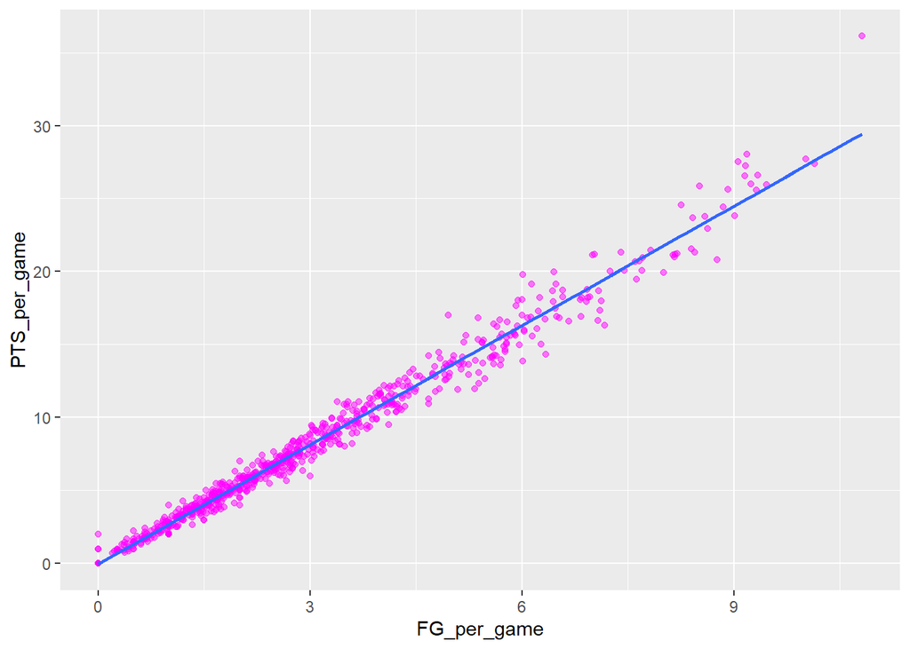

```r
lm_fg <- ggplot(players, aes(x = FG_per_game, y = PTS_per_game)) +
  geom_point(alpha = 0.5, colour = "magenta") +
  geom_smooth(method = "lm", se = FALSE)
lm_fg
```

Examining the other three variables, TOV, RB, FT against PTS_per_game

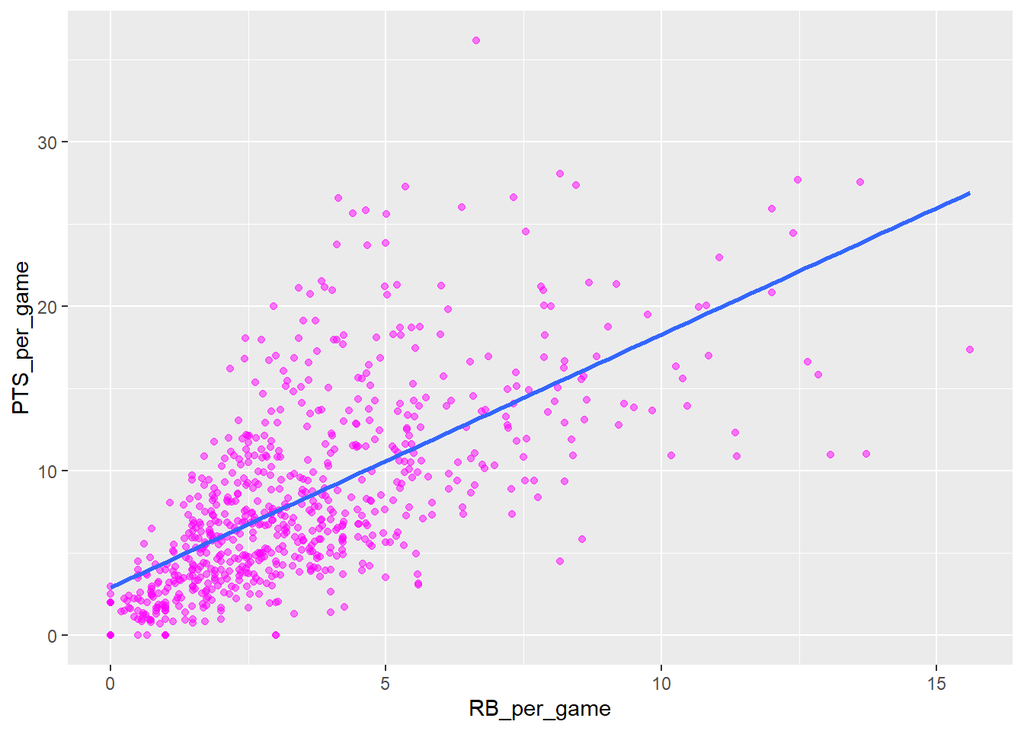

```r
lm_rb <- ggplot(players, aes(x = RB_per_game, y = PTS_per_game)) +
  geom_point(alpha = 0.5, colour = "magenta") +
  geom_smooth(method = "lm", se = FALSE)
lm_rb
```